# GGR 276 Lab 2 Part 2

Scarlett Rakowska

2026-03-09

# Part B1. Sampling Data

## Import Data

If your R Markdown is **NOT** in the same folder as your data, please set your working directory using `setwd()` first. Here is an example if you are using *Medusa* `setwd("\\medusa\StudentWork\(Your UTOR ID)\GGR276\Lab1")` and if you are using your *own computer* ‘setwd(C:/)’. You will need to change the code to reflect your personal directory. Then load your data. When loading in the data try to get your ‘Data variable name’ short and easy to type! If you change it from what is listed in the rmarkdown instructions you will need to change it.

We are loading the same aviation facilities dataset as Assignment 1.

Once the dataset is loaded, you will need to investigate the dataset to determine if you have any NA values. It is also recommended you determine the descriptive statistics before proceeding. We are building on the skills you learned in lab 1. This includes summary statistics and filtering your data. In statistics, each step builds on the previous.

```r
setwd("~/Assignment 1 GGR276/Assignment1")
aviation_facilities <- read.csv("aviationfacilities.csv", sep = ",", header = TRUE)
```

View your dataframe and determine the distribution of the all the variables in this dataframe; are you missing any data?:

```r
#ToDo
summary(aviation_facilities)
```

```
##    EFF_DATE            SITE_NO      SITE_TYPE_CODE      STATE_CODE
##  Length:19707       Min.   :  103   Length:19707       Length:19707
##  Class :character   1st Qu.: 5251   Class :character   Class :character
##  Mode  :character   Median :13294   Mode  :character   Mode  :character
##                     Mean   :15633
##                     3rd Qu.:23404
##                     Max.   :90970
##
##    ARPT_ID              CITY           COUNTRY_CODE       REGION_CODE
##  Length:19707       Length:19707       Length:19707       Length:19707
##  Class :character   Class :character   Class :character   Class :character
##  Mode  :character   Mode  :character   Mode  :character   Mode  :character
##
##
##
##
##    ADO_CODE          STATE_NAME        COUNTY_NAME        COUNTY_ASSOC_STATE
##  Length:19707       Length:19707       Length:19707       Length:19707
##  Class :character   Class :character   Class :character   Class :character
##  Mode  :character   Mode  :character   Mode  :character   Mode  :character
##
##
##
##
##   ARPT_NAME         OWNERSHIP_TYPE_CODE FACILITY_USE_CODE     LAT_DEG
##  Length:19707       Length:19707        Length:19707       Min.   : 5.00
##  Class :character   Class :character    Class :character   1st Qu.:33.00
##  Mode  :character   Mode  :character    Mode  :character   Median :39.00
##                                                            Mean   :38.48
##                                                            3rd Qu.:42.00
##                                                            Max.   :76.00
##
##     LAT_MIN         LAT_SEC       LAT_HEMIS          LAT_DECIMAL
##  Min.   : 0.00   Min.   : 0.00   Length:19707       Min.   :-14.33
##  1st Qu.:15.00   1st Qu.:14.36   Class :character   1st Qu.: 33.97
##  Median :30.00   Median :29.94   Mode  :character   Median : 39.06
##  Mean   :29.68   Mean   :29.56                      Mean   : 38.98
##  3rd Qu.:44.00   3rd Qu.:44.89                      3rd Qu.: 42.77
##  Max.   :59.00   Max.   :60.00                      Max.   : 76.53
##
```

[output cut: 129 more lines]

```
##  Length:19707       Length:19707       Length:19707       Length:19707
##  Class :character   Class :character   Class :character   Class :character
##  Mode  :character   Mode  :character   Mode  :character   Mode  :character
##
##
##
##
##    ICAO_ID          MIN_OP_NETWORK     USER_FEE_FLAG          CTA
##  Length:19707       Length:19707       Length:19707       Length:19707
##  Class :character   Class :character   Class :character   Class :character
##  Mode  :character   Mode  :character   Mode  :character   Mode  :character
##
##
##
##
```

Now that we have looked at the dataframe and know some of the summary statistics, we want to filter the data so that we only keep facilities located in continental USA. We also want to remove NA values from Acreage and Elevation so we can use those variables later for sampling and inferential statistics.

```r
# Filtering the data to subset the dataset:
# We only want facilities where STATE_CODE is in continental USA
# We also remove records with NA values for ACREAGE or ELEV (needed later in the lab)
#ToDo

filtered_states <- subset(
  aviation_facilities,
  (STATE_CODE %in% c("AL","AZ","AR","CA","CO","CT","DE","FL","GA",
  "ID","IL","IN","IA","KS","KY","LA","ME","MD",
  "MA","MI","MN","MS","MO","MT","NE","NV","NH",
  "NJ","NM","NY","NC","ND","OH","OK","OR","PA",
  "RI","SC","SD","TN","TX","UT","VT","VA","WA","DC",
  "WV","WI","WY")) & !is.na(ACREAGE) & !is.na(ELEV)
)

nrow(filtered_states)
```

```
## [1] 9350
```

```r
table(filtered_states$SITE_TYPE_CODE)
```

```
##
##    A    B    C    G    H    U
## 7822    8   94   24 1337   65
```

```r
summary(filtered_states$ACREAGE)
```

```
##    Min. 1st Qu.  Median    Mean 3rd Qu.    Max.
##     0.0    10.0    51.0   286.6   190.0 55000.0
```

```r
summary(filtered_states$ELEV)
```

```
##    Min. 1st Qu.  Median    Mean 3rd Qu.    Max.
##  -210.0   331.1   803.5  1316.5  1420.0  9933.5
```

Now that we have filtered to continental USA, we will focus only on 3 facility types: Airports (A), Heliports (H), and Seaplane Bases (C).

```r
# Use SITE_TYPE_CODE to filter the dataset to only include "A", "H", and "C".

#ToDo
filtered_states <- filtered_states[filtered_states$SITE_TYPE_CODE %in% c("A", "H", "C"),]
```

## Simple Random Sampling

First, we will randomly sample 100 records. from the filtered dataset.

```r
random_sample <- filtered_states[sample(1:nrow(filtered_states), size = 100, replace = FALSE), ]
nrow(random_sample)
```

```
## [1] 100
```

## Stratified Sampling

Next, we will try stratified sampling using dplyr package. In this exercise, we are only interested in facilities where Elevation is greater than 1000 (ELEV > 1000). Therefore, we create a subset first.

```r
# Create a subset consisting of Elevation >= 1000
subset_facilities <- subset(filtered_states, ELEV >= 1000)

nrow(subset_facilities)
```

```
## [1] 3569
```

```r
table(subset_facilities$SITE_TYPE_CODE)
```

```
##
##    A    C    H
## 3199   16  354
```

```r
# Stratified Sampling
library(dplyr)
stratified_sample <- subset_facilities %>%
  group_by(SITE_TYPE_CODE) %>%
  sample_n(size = 10, replace = FALSE) %>%
  ungroup()

nrow(stratified_sample)
```

```
## [1] 30
```

```r
table(stratified_sample$SITE_TYPE_CODE)
```

```
##
##  A  C  H
## 10 10 10
```

(4 marks) **Q7** Now, it is your turn.

Please create a stratified sample consisting of facilities where Elevation is above the 1st quartile elevation, Acreage is above the 1st quartile acreage, and Remove NA values from Elevation and Acreage (already done in filtered_states).

For the stratified sample, you will be using the SITE_TYPE_CODE category. For each category, make the sample size equal to 20. To make the result reproducible, please add code set.seed(123) prior to your sampling.

Please indicate the number of observations in your subset and the number of observations in your stratified sample. You can use summary to find the 1st quartiles.

```r
# ToDo
# Students can use summary() to identify the 1st quartiles (25th percentile)

# Run Summary to determine 1st quartile
summary(filtered_states$ELEV)
```

```
##    Min. 1st Qu.  Median    Mean 3rd Qu.    Max.
##  -210.0   332.6   805.0  1320.5  1430.0  9933.5
```

```r
summary(filtered_states$ACREAGE)
```

```
##    Min. 1st Qu.  Median    Mean 3rd Qu.    Max.
##     0.0    10.0    52.0   288.9   194.0 55000.0
```

```r
# From the summary above we determine the first quartile is 332.6 and can filter data accordingly
subset_facilities <- subset(filtered_states, ELEV > 332.6 & ACREAGE > 10.0)
```

```r
## ToDo

# Creating the stratified sample

# Call dplyr package
library(dplyr)

set.seed(123)

# set sample to 20 and group by site code A, C and H
stratified_sample <- subset_facilities %>%
  group_by(SITE_TYPE_CODE) %>%
  sample_n(size = 20, replace = FALSE) %>%
  ungroup()

# print number of observation in subset
# and under of observations in stratifed sample
nrow(subset_facilities)
```

```
## [1] 5181
```

```r
nrow(stratified_sample)
```

```
## [1] 60
```

```r
# Ensure there is 20 per group
table(stratified_sample$SITE_TYPE_CODE)
```

```
##
##  A  C  H
## 20 20 20
```

## Compare Sampling Technique

(4 marks) **Q8** What is the difference between simple random sampling and stratified sampling? In this case, would you use simple random sampling or stratified sampling?

**Type your response here**

Firstly, recall in simple random sampling, all elements of the data set have the same chance of being selected, making the results truly random. However, the method has draw backs, because some subgroups may be represented disproportionately.

In contrast, the stratified sampling method works by dividing the data set into categories, and then choosing a random sample from each category. This process ensures there will be representation from every category.

Thus, because we focus on three site types within the data (A, C, H), stratified sampling would be a more effective sampling method then random sampling. The stratified method would guarantee each category or in this case site type, is represented in the sample. This is important because it lets us make connects and comparisons between each group.

# Part B2. Inferential Statistics

## Two-sample difference of mean test

(2 marks) **Q9** Does the mean elevation differ between AIRPORT and HELIPORT facilities? Write the null hypothesis and alternate hypothesis?

**Type your response here**

For the null hypothesis:

Ho: The mean elevation of the AIRPORT facilities is the same as (equal) to the elevation of the HELIPORT facilities

For the alternate hypothesis:

Ha: The mean elevation of the AIRPORT facilities is different (not equal) from the elevation of the HELIPORT facilities

(3 marks) **Q10** What would happen if you used a parametric difference of mean test on non-parametric data?

**Type your response here**

Recall that tests for parametric difference assume that the data is normally distributed. Normal distribution entails that the data is symmetric (no skews), the mean, median and mode are clustered at the center peak of the data, and the shape of the data is bell shaped.

Non-parametric data does not have a known distribution, and thus it cannot be assumed that it has the qualities of a normal distribution.

So, if a parametric difference of mean test was used on non-parametric data it would likely produce inaccurate results. This would cause any statistical interpretations of the data to be misleading, potentially casing type 1 and type 2 errors such as, rejecting a true hypothesis or failing to reject a false hypothesis.

(4 marks) **Q11** Please select an appropriate statistical test, and provide justifications by visualizing the distribution, using the stratified sample subset.

**Type your response here**

To choose an appropriate test, I will first visualize the distribution of both the Airport data and Heliport data. I can do this by creating histograms and a Q-Q plots to see the data spread for each sample.

Combining the fact that the numerical data is non-parametric, and that there are two samples, we can conclude the test that meets all criteria is the Wilcoxon rank sum test/ W-Test.

Therefore, I will use the Wilcoxon rank sum test to statistically test the data.

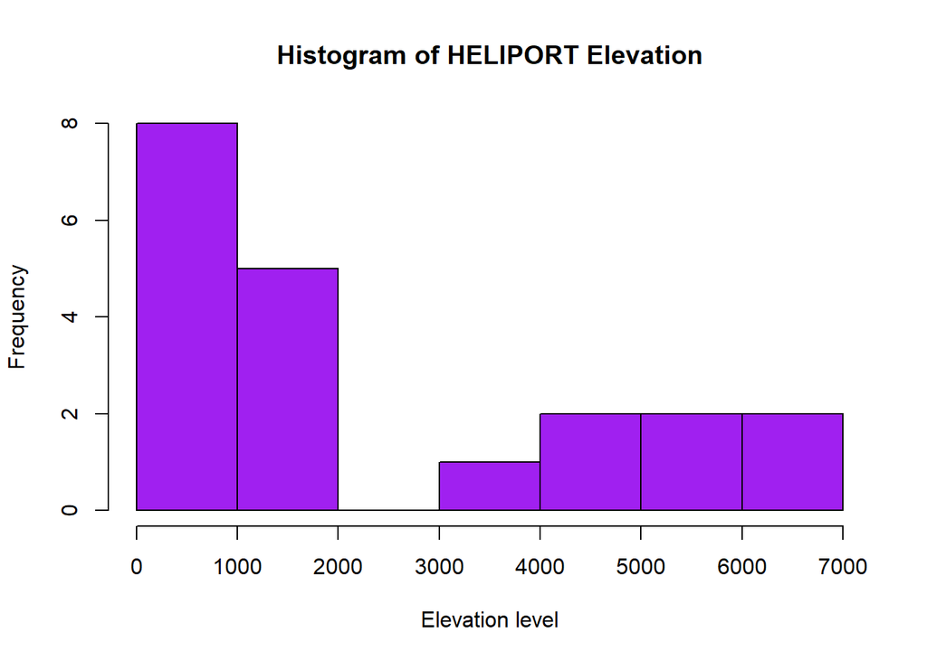

```r
# plot the histogram using the stratified sample created above, focusing on elevation data
airport <- stratified_sample$ELEV[stratified_sample$SITE_TYPE_CODE == "A"]
heliport <- stratified_sample$ELEV[stratified_sample$SITE_TYPE_CODE == "H"]


# FOR HELIPORT DATA
hist(heliport,
     main = "Histogram of HELIPORT Elevation",
     xlab = "Elevation level",
     ylab = "Frequency",
     col= "purple")
```

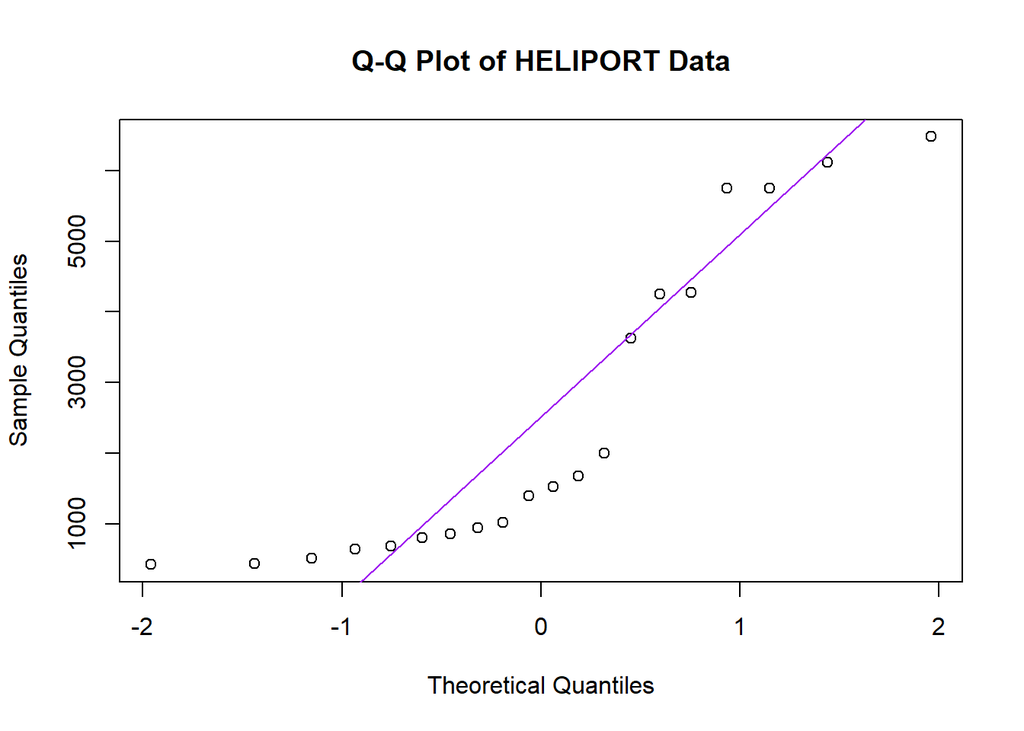

```r
# plot the Q-Q Plot using qqnorm() and sample data
qqnorm(heliport, main= "Q-Q Plot of HELIPORT Data")
qqline(heliport, col="purple")
```

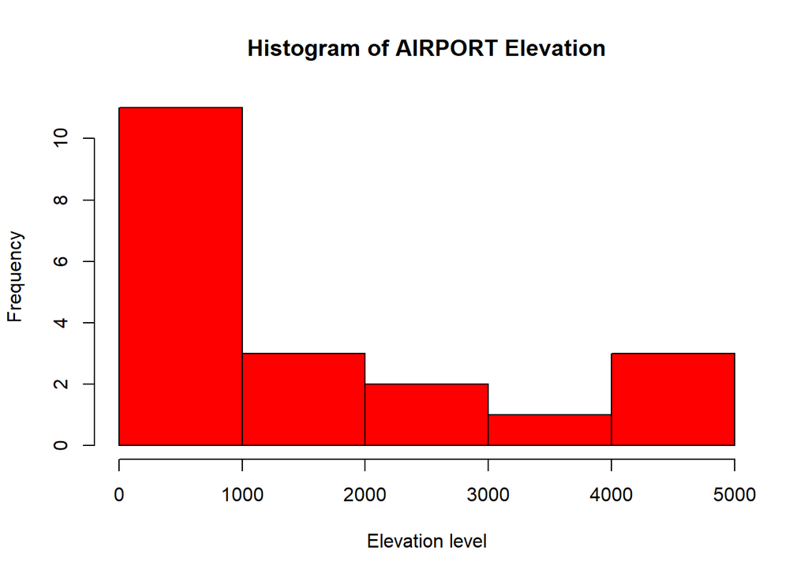

```r
# FOR AIRPORT DATA
hist(airport,
     main = "Histogram of AIRPORT Elevation",
     xlab = "Elevation level",
     ylab = "Frequency",
     col= "red")
```

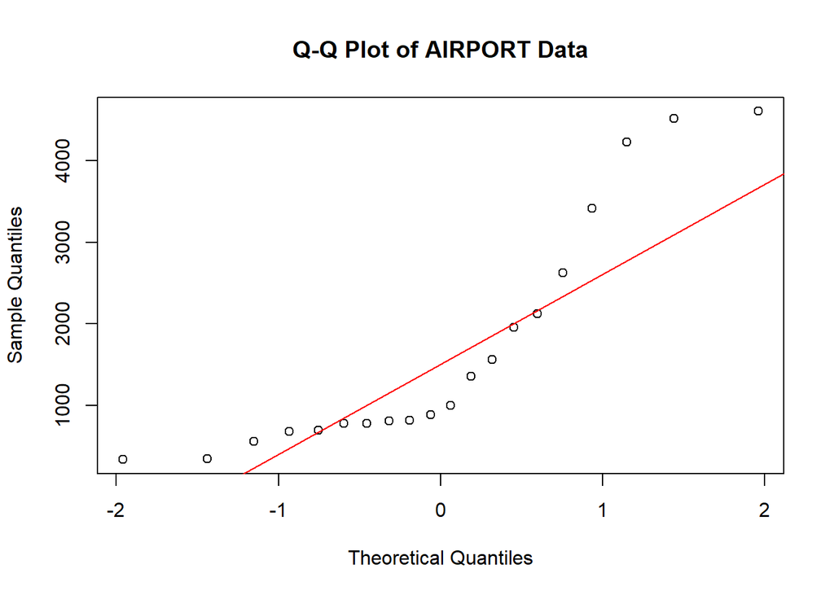

```r
# plot the Q-Q Plot using qqnorm() and sample data
qqnorm(airport, main= "Q-Q Plot of AIRPORT Data")
qqline(airport, col="red")
```

(6 marks) **Q12** Please conduct the statistic test and interpret the results. Create 2 vectors (airport and heliport), each containing elevation values from each facility type. Then use a non-parametric difference of means test.

```r
#Create two vectors from the stratified sample to represent facility types A and H for elevation data

airport <- stratified_sample$ELEV[stratified_sample$SITE_TYPE_CODE == "A"]
heliport <- stratified_sample$ELEV[stratified_sample$SITE_TYPE_CODE == "H"]

# use the 2 vectors to preform a non-parametric difference of means test
wilcox.test(airport, heliport)
```

```
##
##  Wilcoxon rank sum test with continuity correction
##
## data:  airport and heliport
## W = 165.5, p-value = 0.3577
## alternative hypothesis: true location shift is not equal to 0
```

**Type the statistic results and interpretation here**

After using the Wilcoxon rank sum test, we see that the p-value is equal too 0.3577. This value is greater then the significance level of 0.05. Thus, we fail to reject the null hypothesis (Ho), and conclude that there is not enough evidence to show a significant difference in mean elevation between the airport and heliport facilities.

## Three-sample Mean Difference Test

(8 marks) **Q13** Please follow the same procedure above to test whether the 1st quartile elevation differs between facility types.

**Type your response here**:

— HYPOTHESES —

First, we must establish our null hypothesis and alternate hypothesis regarding the question.

The null hypothesis is: Ho: the mean elevations above the first quartile across all facility types (A/H/C) is the same (equal).

The alternate hypothesis is: Ha: at least one of more mean elevations above the first quartile of all facility types (A/H/C) is different from the others (not equal).

— TEST ASSUMPTIONS AND CHOOSING TEST —

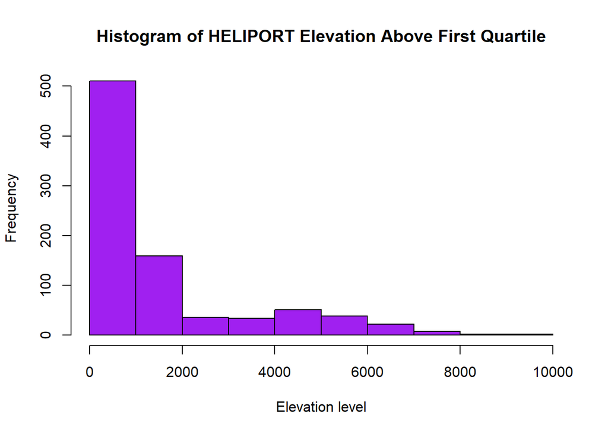

```r
#ToDo
# Visualize Distribution (1 mark)

# First create a 1st quartile elevation only (we know the first quartile from
# previous questions)
first_quart_facilities <- subset(filtered_states, ELEV > 332.6)

airport_data <- first_quart_facilities$ELEV[first_quart_facilities$SITE_TYPE_CODE == "A"]
heliport_data <- first_quart_facilities$ELEV[first_quart_facilities$SITE_TYPE_CODE == "H"]
sea_base_data <- first_quart_facilities$ELEV[first_quart_facilities$SITE_TYPE_CODE == "C"]

# FOR HELIPORT DATA
hist(heliport_data,
     main = "Histogram of HELIPORT Elevation Above First Quartile",
     xlab = "Elevation level",
     ylab = "Frequency",
     col= "purple")
```

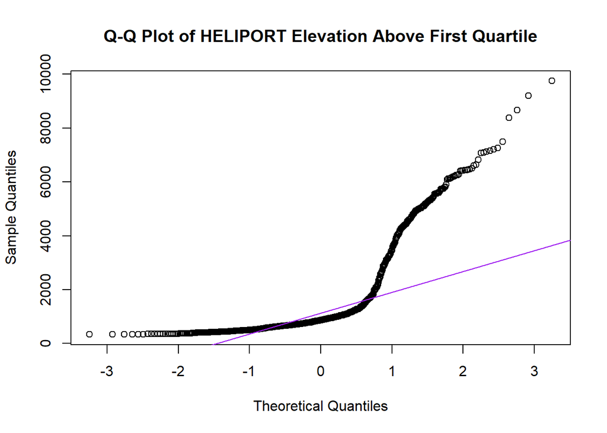

```r
# plot the Q-Q Plot using qqnorm() and sample data
qqnorm(heliport_data, main= "Q-Q Plot of HELIPORT Elevation Above First Quartile")
qqline(heliport_data, col="purple")
```

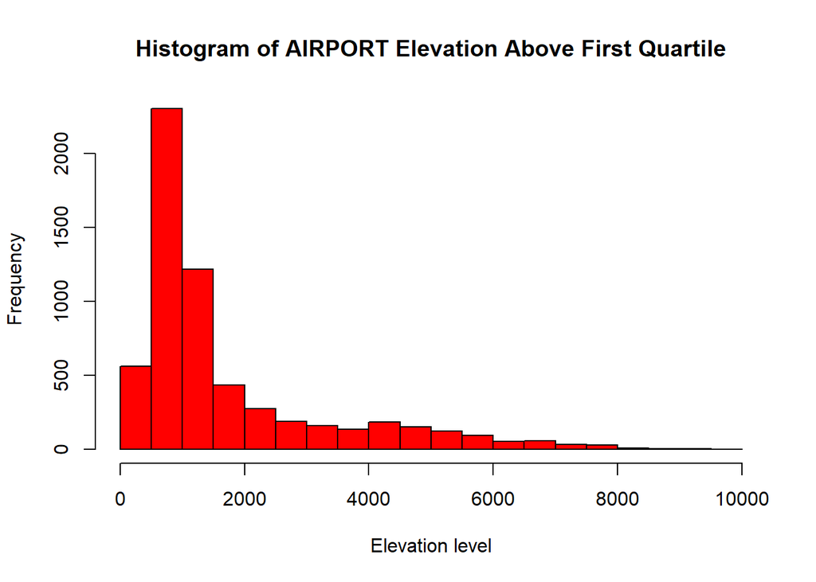

```r
# FOR AIRPORT DATA
hist(airport_data,
     main = "Histogram of AIRPORT Elevation Above First Quartile",
     xlab = "Elevation level",
     ylab = "Frequency",
     col= "red")
```

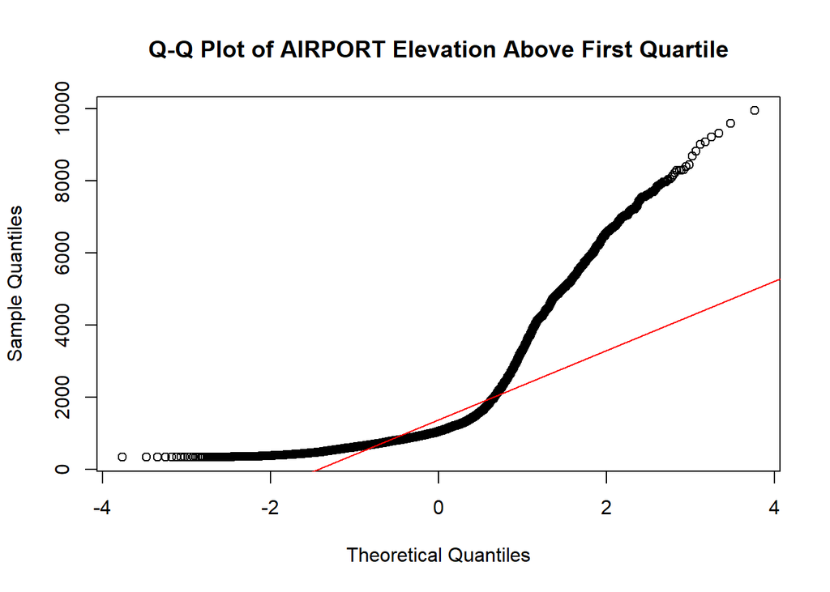

```r
# plot the Q-Q Plot using qqnorm() and sample data
qqnorm(airport_data, main= "Q-Q Plot of AIRPORT Elevation Above First Quartile")
qqline(airport_data, col="red")
```

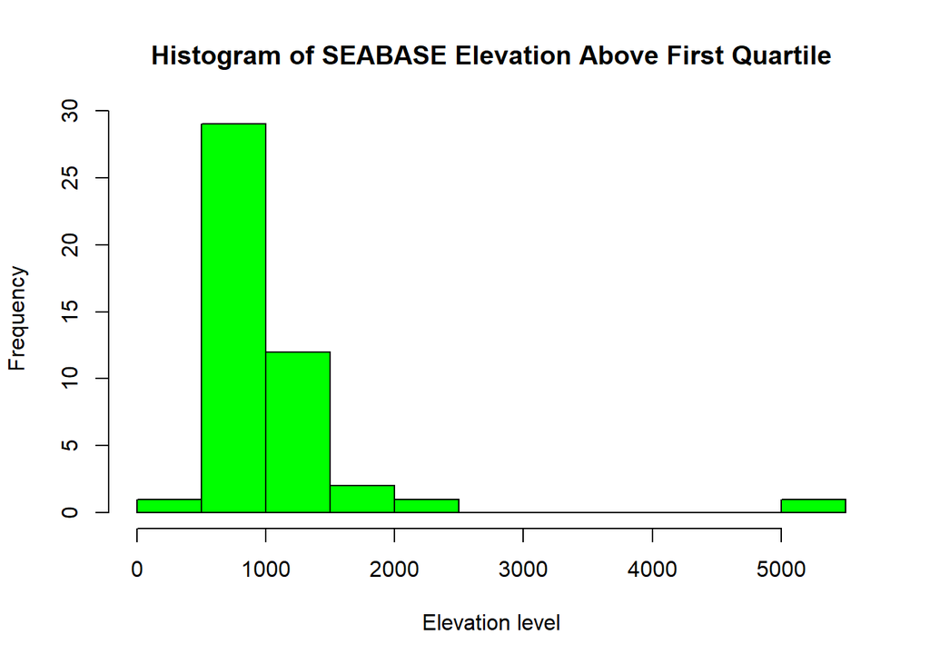

```r
# FOR SEABASE DATA
hist(sea_base_data,
     main = "Histogram of SEABASE Elevation Above First Quartile",
     xlab = "Elevation level",
     ylab = "Frequency",
     col= "green")
```

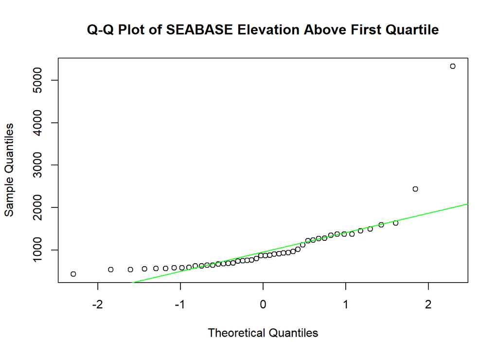

```r
# plot the Q-Q Plot using qqnorm() and sample data
qqnorm(sea_base_data, main= "Q-Q Plot of SEABASE Elevation Above First Quartile")
qqline(sea_base_data, col="green")
```

```r
#ToDo
# ANOVA Test (2 marks) using the filtered dataset (A/H/C)

# To run the test use the aov() function and input the weight, group and data
anova_test <- aov(ELEV ~ SITE_TYPE_CODE, data = first_quart_facilities)

# print out the summary of the anova test
summary(anova_test)
```

```
##                  Df    Sum Sq  Mean Sq F value  Pr(>F)
## SITE_TYPE_CODE    2 2.943e+07 14714157   5.503 0.00409 **
## Residuals      6936 1.855e+10  2673925
## ---
## Signif. codes:  0 '***' 0.001 '**' 0.01 '*' 0.05 '.' 0.1 ' ' 1
```

#Type 1 and Type 2 error (4 marks) **Q14** Discuss what the Type 1 and Type 2 errors would be for both your 2-sample and 3-sample difference of means tests. Why is it important to understand Type 1 and Type 2 errors?

Recall a type 1 error is when a true null hypothesis is rejected and a type 2 error is when there is a failure to reject a false null hypothesis.

for the 2-sample difference of means test, the TYPE 1 error would be REJECTING that the mean elevation of the AIRPORT facilities is equal to the elevation of the HELIPORT facilities, and concluding that they are different, even through they are the same. The Type 2 error would be NOT rejecting that the mean elevation of the AIRPORT facilities is equal to the elevation of the HELIPORT facilities, concluding they are same, even through they are the different.

for the 3-sample difference of means test, the Type 1 error would be REJECTING that the elevation levels between facility types are the same, and concluding at least one differs, even when no difference exists. The Type 2 error would be NOT REJECTING that the elevation levels between facility types are the same, and concluding that there there is no differences, when in fact there are.

Understanding these errors is important because it helps validate statistical findings. This is because it helps one understand that hypotheses are uncertain, and mistakes can occur when making conclusions about data. It may even be relevant question 13, where we conducted an ANOVA test on data that may have been non-parametric. Overall understanding the error types make us interpret data more meticulously to avoid mistake.